# Managing Your Data Pipeline: From Wrangling to Visualizing Your Data in R

Liz Beard

1/28/2021

## Project Background

Does the way information is presented to us influence risky choice?

24 adults participated in an fMRI study where they were asked to make a series of choices between different lotteries In one condition, participants learned via **description** were shown visual representations of the lotteries. In the other, partcipants learned from **experience**, and were allowed to sample from the two lotteries before choosing which they would ultimately like play.

- 4 blocks (2 description, 2 experience)
- 36 choices per condition
- 72 trials/subject

## Codebook

To get a sense of what our data is going to look like, let’s check out the [codebook](https://docs.google.com/document/d/1CNf82TKctKWUeFgptXHa3d8Ij4UzjeAh0U3u-x15_L8/edit?usp=sharing).

## Getting Started

```r
# read in our libraries
library(dplyr)
library(ggplot2)
library(sjPlot)
library(wesanderson)
library(ggstatsplot)
library(lme4)
library(lmerTest)
library(stargazer)
library(effects)

# read in our data
df = read.csv('/Volumes/GoogleDrive/Shared drives/DEGap/DEAL-fMRI/data/behav/DEAL-degap_big.csv')
head(df)
```

|  | TrialNumber | P1_1 | P1_2 | SafeOption | P2_2 | O2_2 | O2_1 | ProbNumber | probFormat | O1_2 | O1_1 | EV2 | EV1 | ProbType | P2_1 | ran | order | trialStartTime | samplingCount_total | samplingCount_risky | samplingCount_safe | switchCount | acqDur_assigned | acqDur_total | acqEndTime | thinkOnset | decideOnset | leftRight | resp | … |
| --- | --- | --- | --- | --- | --- | --- | --- | --- | --- | --- | --- | --- | --- | --- | --- | --- | --- | --- | --- | --- | --- | --- | --- | --- | --- | --- | --- | --- | --- | --- |
| 1 | 1 | 0.5 | 0.3 | 1 | 0.7 | 35 | 30 | RR5 | ebdm | -10 | 10 | 21.5 | 20.0 | RR | 0.5 | 1 | 0 | 11.0057 | 8 | 0 | 8 | 0 | 16 | 15.5124 | 26.5182 | 26.5190 | 29.5373 | 0 | 1 | … |
| 2 | 2 | 0.7 | 0.1 | 1 | 0.9 | 30 | 38 | RR11 | ebdm | -10 | 22 | 26.0 | 26.8 | RR | 0.3 | 1 | 1 | 35.8101 | 13 | 7 | 6 | 6 | 15 | 14.7774 | 50.5875 | 50.5882 | 53.6071 | 1 | 2 | … |
| 3 | 3 | 0.1 | 1.0 | 2 | 0.0 | 0 | 0 | SD1 | ebdm | -3 | -32 | -3.0 | -3.2 | SD | 0.9 | 1 | 2 | 63.7996 | 8 | 4 | 4 | 7 | 15 | 14.5112 | 78.3108 | 78.3115 | 81.3298 | 1 | 1 | … |
| 4 | 4 | 0.4 | 1.0 | 2 | 0.0 | 0 | 0 | SD11 | ebdm | 8 | 22 | 8.0 | 8.8 | SD | 0.6 | 1 | 3 | 86.0012 | 12 | 6 | 6 | 11 | 15 | 14.5111 | 100.5120 | 100.5130 | 103.5320 | 1 | 1 | … |
| 5 | 5 | 0.4 | 1.0 | 2 | 0.0 | 0 | -20 | MD4 | ebdm | -4 | 15 | -4.0 | -6.0 | MD | 0.6 | 1 | 4 | 108.1030 | 17 | 9 | 8 | 16 | 15 | 14.5602 | 122.6630 | 122.6640 | 125.6830 | 0 | 1 | … |
| 6 | 6 | 0.6 | 1.0 | 2 | 0.0 | 0 | -12 | MD12 | ebdm | 12 | 30 | 12.0 | 13.2 | MD | 0.4 | 1 | 5 | 131.7220 | 16 | 8 | 8 | 15 | 17 | 16.5129 | 148.2350 | 148.2360 | 151.2540 | 1 | 2 | … |

## Data Cleaning

How many trials did participants miss?

```r
sum(is.na(df$safeChoice))
```

```
## [1] 54
```

Uh oh! One of the choice types doesn’t have similar expected value (one choice is mathematically superior to the other). Let’s remove that from the dataset we’ll use for our analyses, as well as the null repsonses.

```r
df.s <- subset(df, !is.na(resp) & ProbNumber != 'MD3')
```

## Does the way information is presented to us influence risky choice?

```r
m1 <- glmer(safeChoice ~ (1|subj) + probFormat, family=binomial(), data=df.s)
stargazer(m1, type='text', covariate.labels=c('Information Condition'), dep.var.labels=c('Risky Choice (OR)'))
```

```
##
## =================================================
##                           Dependent variable:
##                       ---------------------------
##                            Risky Choice (OR)
## -------------------------------------------------
## Information Condition          0.303***
##                                 (0.101)
##
## Constant                       -0.534***
##                                 (0.115)
##
## -------------------------------------------------
## Observations                     1,714
## Log Likelihood                -1,136.102
## Akaike Inf. Crit.              2,278.203
## Bayesian Inf. Crit.            2,294.543
## =================================================
## Note:                 *p<0.1; **p<0.05; ***p<0.01
```

Let’s visualize this model! Since we’re using a *really* simple model, we probably only need to look at a bar plot. But interpretting odds ratios for logistic regression isn’t always intuitive. We can use the effects package to transform our beta values into predictive probabilties.

```r
class(m1) <- 'lmerMod'
m1.estimates <- effect('probFormat', m1)
m1.estimates.df <- data.frame(m1.estimates)
m1.estimates.df
```

|  | probFormat | fit | se | lower | upper |
| --- | --- | --- | --- | --- | --- |
| 1 | dbdm | 0.3695731 | 0.02670378 | 0.3189312 | 0.4232589 |
| 2 | ebdm | 0.4425225 | 0.02797046 | 0.3886116 | 0.4978225 |

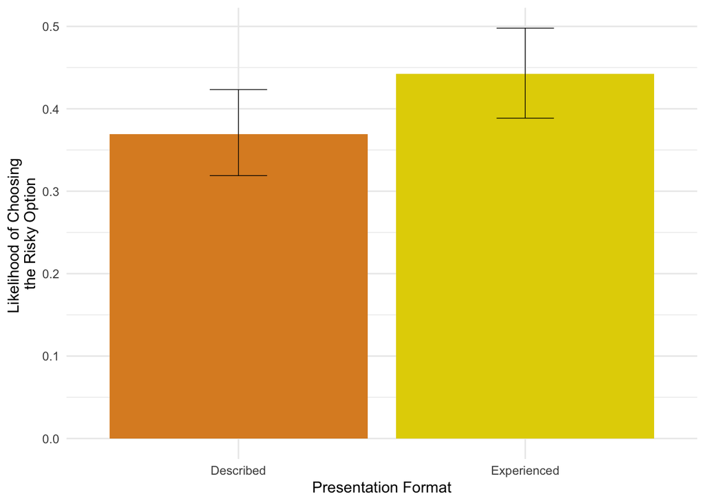

```r
m1.estimates.df$probFormat <- ordered(m1.estimates.df$probFormat,
                                      levels = c('dbdm', 'ebdm'),
                                      labels = c('Described', 'Experienced'))

g1 <- ggplot(m1.estimates.df, aes(x=probFormat, y=fit)) +
  geom_bar(stat='identity', position=position_dodge(), fill=wes_palette('FantasticFox1',n=2)) +
  geom_errorbar(aes(ymin=lower, ymax=upper), width=.2, size=.25, position=position_dodge(.9)) +
  ylab('Likelihood of Choosing \nthe Risky Option') + xlab('Presentation Format') +
  theme_minimal()
g1
```

## What about a more complex model?

Does the valence of the rare option in the lottery impact the relationship between information condition and choice?

```r
# first we have to code whether the rare outcome was favorable (positive relative to the common outcome),
# or unfavorable (negative relative to the common outcome)

# let's find the probably and monetary value of the frequent outcome
df.s$PFreq <- ifelse(df.s$P1_1 > .5, df.s$P1_1, df.s$P2_1)
df.s$OFreq <- ifelse(df.s$P1_1 > .5, df.s$O1_1, df.s$O2_1)

# probability and monetary value of the rare outcome
df.s$PRare <- ifelse(df.s$P1_1 < .5, df.s$P1_1, df.s$P2_1)
df.s$ORare <- ifelse(df.s$P1_1 < .5, df.s$O1_1, df.s$O2_1)

# if we have a .50.50 probability, let's list it as NA for now (it won't be included in our analyses)
df.s$ORare[df.s$PRare==.5|df.s$PFreq==.5] <- NA
df.s$OFreq[df.s$PRare==.5|df.s$PFreq==.5] <- NA
df.s$PRare[df.s$PRare==.5] <- NA
df.s$PFreq[df.s$PFreq==.5] <- NA

# coding whether the monetary value of the rare outcome is greater than the frequent outome
df.s$RareFav <- ifelse(df.s$ORare > df.s$OFreq, 1, 0) # here, zero could be anything (depends on Rare Fav)
df.s$RareFav <- factor(df.s$RareFav, levels=c(0,1), labels=c('Rare Unfavorable', 'Rare Favorable'))


# let's build our model
m2 <- glmer(safeChoice ~ (1|subj) + RareFav*probFormat, family=binomial(), data=df.s)
stargazer(m2, type='text', covariate.labels=c('Information Condition', 'Outcome Favorablility', 'Condition*Favorability'),
          dep.var.labels=c('Risky Choice (OR)'))
```

```
##
## ==================================================
##                            Dependent variable:
##                        ---------------------------
##                             Risky Choice (OR)
## --------------------------------------------------
## Information Condition           0.426***
##                                  (0.149)
##
## Outcome Favorablility           0.668***
##                                  (0.150)
##
## Condition*Favorability          -0.735***
##                                  (0.208)
##
## Constant                        -0.726***
##                                  (0.138)
##
## --------------------------------------------------
## Observations                      1,614
## Log Likelihood                 -1,069.302
## Akaike Inf. Crit.               2,148.605
## Bayesian Inf. Crit.             2,175.537
## ==================================================
## Note:                  *p<0.1; **p<0.05; ***p<0.01
```

Now, we could visualize the model the same way, using ggplot2. But what if we want to emphasize the fact that the way information is presented *and* outcome favorability shift people’s choice behavior? This is where I prefer sjPlot.

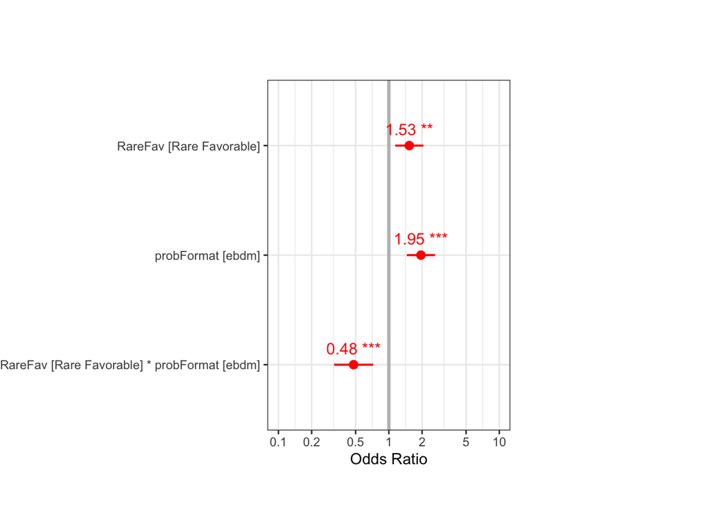

```r
plot_model(m2, type = "est",show.ci = TRUE, show.p=TRUE, show.values=TRUE, title="",
           legend.title=c('Format'), axis.title=c('Odds Ratio'),
           colors=wes_palette('Darjeeling1',n=1), vline.color='grey') +
  theme_bw() + theme(plot.margin=margin(2,5,1,0,'cm'))
```

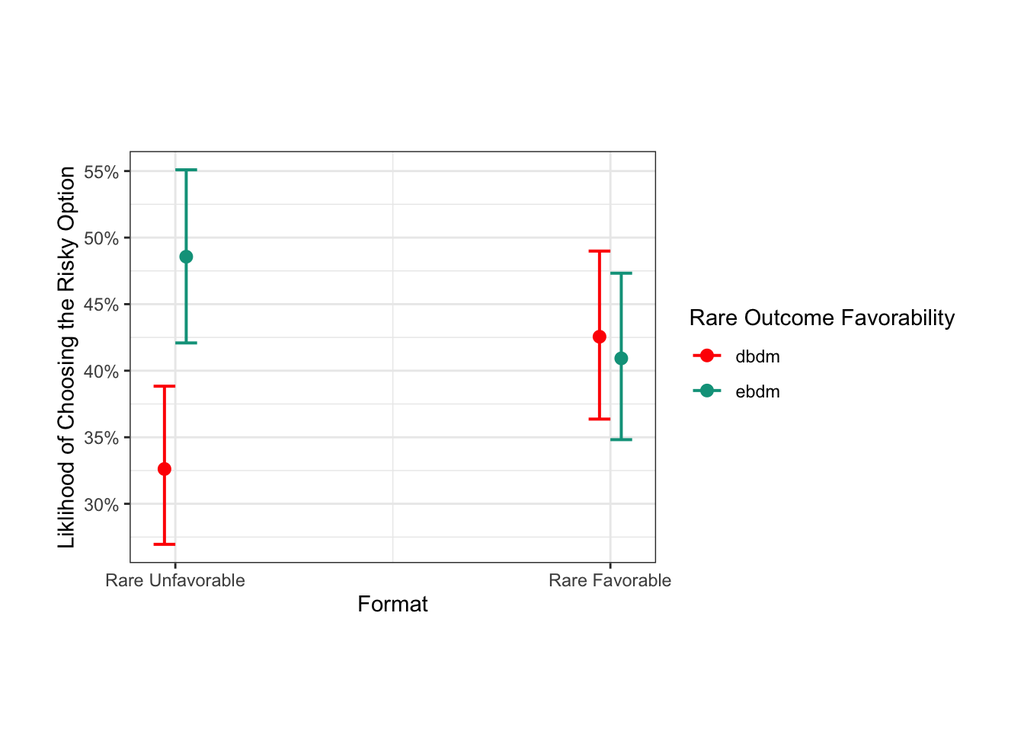

```r
plot_model(m2, type='int', colors=wes_palette('Darjeeling1',n=2), title="", axis.title=c('Format', 'Liklihood of Choosing the Risky Option'), legend.title='Rare Outcome Favorability') + theme_bw() + theme(plot.margin=margin(2,1,2,1, 'cm'))
```

## Does RT differ between our two information conditions?

Let’s assume we are assessing this as an exploratory question. Ggstatsplot is great for performing analyses that are more exploratory since they provide you with so much information in a single graph!

```r
ggwithinstats(df.s, probFormat, rt, title='', point.path = FALSE, xlab='Format', ylab='Reaction Time (s)')
```

```
## Note: Shapiro-Wilk Normality Test for Reaction Time (s): p-value = < 0.001
```

```
## Note: Bartlett's test for homogeneity of variances for factor Format: p-value = 0.725
```

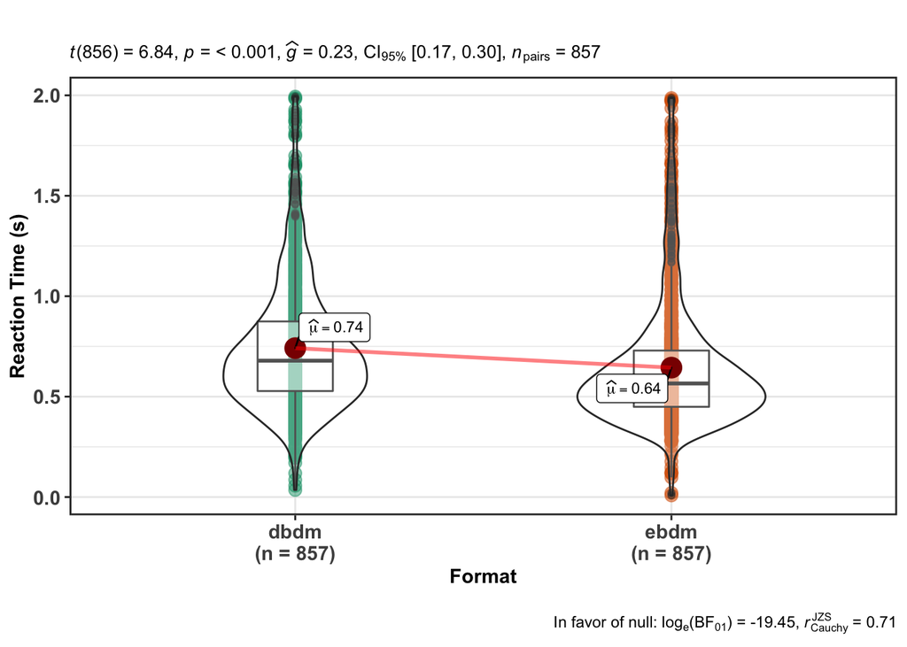